# Logistic Regression

Machine Learning for Finance

Author

Mike Aguilar

# Housekeeping

```r
cat("\014")  # clear the console when run interactively
```

```r
rm(list = ls())  # begin from a clean workspace

if (!requireNamespace("here", quietly = TRUE)) {
  stop("Install the 'here' package before rendering this document.")
}

suppressPackageStartupMessages(library(here))
source(here("Supporting", "ProjectSetup.R"))
```

# Background

- Suppose you manage an actively selected equity portfolio.
- You want to identify companies at elevated risk of experiencing a bad earnings quarter.
- You use currently available financial ratios and sector information to estimate that probability.
- The predicted probability serves as a portfolio risk signal. Companies with sufficiently high predicted probabilities may receive additional research, be underweighted, or be excluded from the portfolio.
- We will estimate a simple logistic regression and then a model containing all available predictors.
- We will reserve a test sample for final evaluation. All data-dependent choices, including standardization and the definition of the target, will be based on the training sample.
- We assume that all predictors are available to the investor before the earnings quarter being predicted.

# Data

## Acquisition

Task: Load the data dictionary from the `Data_Dictionary` sheet of `earnings_ratio_data.xlsx`.

```r
data_dictionary <- readxl::read_excel(
  here("data", "earnings_ratio_data.xlsx"),
  sheet = "Data_Dictionary"
)

data_dictionary
```

```
# A tibble: 18 × 6
   variable                  description             units type  category source
   <chr>                     <chr>                   <chr> <chr> <chr>    <chr>
 1 Company_ID                Company identifier      Iden… Char… Identif… Simul…
 2 Sector                    GICS sector classifica… Cate… Char… Classif… Simul…
 3 PE                        Price-to-earnings ratio Mult… Nume… Valuati… Simul…
 4 PB                        Price-to-book ratio     Mult… Nume… Valuati… Simul…
 5 EV_EBITDA                 Enterprise value-to-EB… Mult… Nume… Valuati… Simul…
 6 PS                        Price-to-sales ratio    Mult… Nume… Valuati… Simul…
 7 Div_Yield                 Dividend yield          Deci… Nume… Valuati… Simul…
 8 GPM                       Gross profit margin     Deci… Nume… Profita… Simul…
 9 OpMargin                  Operating margin        Deci… Nume… Profita… Simul…
10 ROA                       Return on assets        Deci… Nume… Profita… Simul…
11 ROE                       Return on equity        Deci… Nume… Profita… Simul…
12 EBITDA_Margin             EBITDA margin           Deci… Nume… Profita… Simul…
13 AssetTurn                 Asset turnover          Turn… Nume… Efficie… Simul…
14 InvTurn                   Inventory turnover      Turn… Nume… Efficie… Simul…
15 ReceivTurn                Receivables turnover    Turn… Nume… Efficie… Simul…
16 FixedAssetTurn            Fixed asset turnover    Turn… Nume… Efficie… Simul…
17 WCTurn                    Working capital turnov… Turn… Nume… Efficie… Simul…
18 Quarterly_Earnings_Growth Quarterly earnings gro… Perc… Nume… Outcome  Simul…
```

Q: Before loading the data, what signs and relative predictive strength do you expect from the variables?

A: There is no uniquely correct answer because these are *a priori* expectations. The signs should be motivated by economic reasoning. For example, stronger profitability or efficiency would generally be expected to reduce the probability of bad earnings, while the expected signs of some valuation ratios may be less obvious. Sector may capture structural differences across businesses. An identifier such as `Company_ID` should not be used as an economic predictor. Correlation among ratios may also make an individual coefficient appear weak even when the broader group of variables is useful.

Task: Load the data and inspect its structure.

```r
earnings_data <- readxl::read_excel(
  here("data", "earnings_ratio_data.xlsx"),
  sheet = "Data"
)

dplyr::glimpse(earnings_data)
```

```
Rows: 1,500
Columns: 18
$ Company_ID                <chr> "Company0001", "Company0002", "Company0003",…
$ Sector                    <chr> "Consumer Discretionary", "Technology", "Ind…
$ PE                        <dbl> 18.97393, 40.58958, 23.30710, NA, 12.72930, …
$ PB                        <dbl> 2.527021, 3.296134, 3.729032, 1.402049, 1.58…
$ EV_EBITDA                 <dbl> 7.637561, 19.283472, 13.261110, 7.027949, 7.…
$ PS                        <dbl> 2.703731, 6.377294, 2.787467, 1.380714, 1.82…
$ Div_Yield                 <dbl> 0.015186304, 0.016985672, 0.018340809, 0.010…
$ GPM                       <dbl> 0.4211754, 0.5015492, 0.3253628, 0.3777786, …
$ OpMargin                  <dbl> 0.12052555, 0.22843628, 0.13133152, 0.140127…
$ ROA                       <dbl> 0.054483486, 0.060010346, 0.011436896, 0.070…
$ ROE                       <dbl> 0.085219299, 0.065657578, 0.015776019, 0.119…
$ EBITDA_Margin             <dbl> 0.13962009, 0.33739587, 0.06500254, 0.290556…
$ AssetTurn                 <dbl> 0.7161599, 1.3264338, 1.2368180, 0.5393658, …
$ InvTurn                   <dbl> 7.790474, 9.202055, 13.488064, 3.087483, 5.6…
$ ReceivTurn                <dbl> 5.184686, 6.978597, 13.037751, 7.515989, 9.2…
$ FixedAssetTurn            <dbl> 2.250918, 6.180342, 5.482202, NA, 3.056688, …
$ WCTurn                    <dbl> 10.617325, 7.748883, 5.351618, 11.659959, 3.…
$ Quarterly_Earnings_Growth <dbl> 3.5245218, 5.2858519, 5.3555893, 5.3913499, …
```

## Clean

Task: Determine the dimensions of the dataset.

```r
dim(earnings_data)
```

```
[1] 1500   18
```

Task: Confirm the number of rows and unique companies.

```r
earnings_data %>%
  summarise(
    rows = n(),
    unique_companies = n_distinct(Company_ID),
    duplicated_company_ids = rows - unique_companies
  )
```

```
# A tibble: 1 × 3
   rows unique_companies duplicated_company_ids
  <int>            <int>                  <int>
1  1500             1500                      0
```

Task: Count the total number of missing cells.

```r
sum(is.na(earnings_data))
```

```
[1] 444
```

Task: Count the number of companies with and without at least one missing value.

```r
earnings_data %>%
  summarise(
    companies_with_missing = sum(if_any(everything(), is.na)),
    companies_without_missing = sum(!if_any(everything(), is.na))
  )
```

```
# A tibble: 1 × 2
  companies_with_missing companies_without_missing
                   <int>                     <int>
1                    386                      1114
```

Task: Retain a copy of the original data and drop companies with any missing values.

```r
earnings_data_raw <- earnings_data

earnings_data <- earnings_data %>%
  filter(!if_any(everything(), is.na))
```

Complete-case deletion is convenient for this exercise. In an applied project, we would first investigate why the values are missing and consider whether deletion could create bias.

Task: Determine the dimensions of the remaining dataset.

```r
dim(earnings_data)
```

```
[1] 1114   18
```

## Split the Sample

Q: Why might we not want to use the entire dataset to train our model?

A:

- We should split the data into training and test samples.
- This keeps the test sample independent of model development.

Task: Randomly assign 80% of the companies to the training sample and 20% to the test sample.

```r
set.seed(123)

train_companies <- earnings_data %>%
  distinct(Company_ID) %>%
  slice_sample(prop = 0.80) %>%
  pull(Company_ID)

train_data_raw <- earnings_data %>%
  filter(Company_ID %in% train_companies)

test_data_raw <- earnings_data %>%
  filter(!Company_ID %in% train_companies)

sample_sizes <- tibble(
  Sample = c("Training", "Test"),
  Rows = c(nrow(train_data_raw), nrow(test_data_raw)),
  Companies = c(
    n_distinct(train_data_raw$Company_ID),
    n_distinct(test_data_raw$Company_ID)
  )
)

knitr::kable(sample_sizes)
```

| Sample | Rows | Companies |
| --- | --- | --- |
| Training | 891 | 891 |
| Test | 223 | 223 |

## Define “Bad” Earnings

Q: How might we define a bad earnings quarter?

A:

- Possible definitions include negative earnings growth, growth below an economically meaningful cutoff, a covenant violation, a material earnings miss, or membership in the lower tail of the historical distribution.
- The definition should reflect the portfolio manager’s investment objective and tolerance for downside risk.
- For this exercise, a bad quarter is one whose earnings growth is at or below the 15th percentile of the *training-sample* distribution.

Task: Plot the training-sample distribution of quarterly earnings growth.

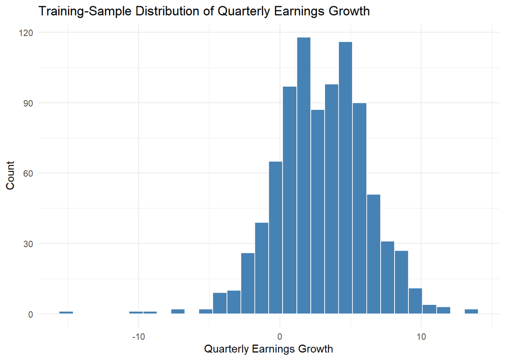

```r
ggplot(train_data_raw, aes(x = Quarterly_Earnings_Growth)) +
  geom_histogram(bins = 30, fill = "steelblue", color = "white") +
  labs(
    title = "Training-Sample Distribution of Quarterly Earnings Growth",
    x = "Quarterly Earnings Growth",
    y = "Count"
  ) +
  theme_minimal()
```

Task: Generate a detailed statistical summary of quarterly earnings growth in the training sample.

```r
earnings_summary <- train_data_raw %>%
  summarise(
    n = n(),
    min = min(Quarterly_Earnings_Growth),
    q10 = quantile(Quarterly_Earnings_Growth, 0.10),
    q25 = quantile(Quarterly_Earnings_Growth, 0.25),
    median = median(Quarterly_Earnings_Growth),
    mean = mean(Quarterly_Earnings_Growth),
    stdev = sd(Quarterly_Earnings_Growth),
    q75 = quantile(Quarterly_Earnings_Growth, 0.75),
    q90 = quantile(Quarterly_Earnings_Growth, 0.90),
    max = max(Quarterly_Earnings_Growth)
  )

knitr::kable(earnings_summary, digits = 3)
```

| n | min | q10 | q25 | median | mean | stdev | q75 | q90 | max |
| --- | --- | --- | --- | --- | --- | --- | --- | --- | --- |
| 891 | -15.131 | -0.84 | 0.94 | 3.006 | 3 | 3.163 | 5.104 | 6.938 | 13.543 |

Task: Let’s use the 15%-quantile as the cut off for bad earnings. Create a `params` list containing the target quantile and a corresponding earnings-growth cutoff.

```r
params <- list(
  bad_quantile = 0.15,
  bad_threshold = as.numeric(
    quantile(
      train_data_raw$Quarterly_Earnings_Growth,
      probs = 0.15
    )
  )
)

params
```

```
$bad_quantile
[1] 0.15

$bad_threshold
[1] -0.005793623
```

Q: What does `bad_threshold` mean?

A:

- The estimated cutoff is -0.006 in the units used for `Quarterly_Earnings_Growth`.
- Approximately 15% of the training observations are at or below this value and are labeled as bad earnings quarters.
- The same fixed cutoff is then applied to the test sample, whose bad-quarter share need not equal exactly 15%.

Task: Create the observed target variable in both samples. Set it equal to 1 for a bad earnings quarter and 0 otherwise. Then tabulate the fraction of observations that are “Bad” in each sample.

```r
train_data_raw <- train_data_raw %>%
  mutate(
    Bad_Earnings = as.integer(
      Quarterly_Earnings_Growth <= params$bad_threshold
    )
  )

test_data_raw <- test_data_raw %>%
  mutate(
    Bad_Earnings = as.integer(
      Quarterly_Earnings_Growth <= params$bad_threshold
    )
  )

tibble(
  Sample = c("Training", "Test"),
  Bad_Earnings_Rate = c(
    mean(train_data_raw$Bad_Earnings),
    mean(test_data_raw$Bad_Earnings)
  )
) %>%
  knitr::kable(digits = 3)
```

| Sample | Bad_Earnings_Rate |
| --- | --- |
| Training | 0.150 |
| Test | 0.135 |

Task: Add a classification-probability threshold of 65% to `params`.

```r
params$prob_threshold <- 0.65
params
```

```
$bad_quantile
[1] 0.15

$bad_threshold
[1] -0.005793623

$prob_threshold
[1] 0.65
```

Q: What is the conceptual difference between `bad_threshold` and `prob_threshold`?

A: `bad_threshold` is a cutoff on *observed earnings growth*. It creates the actual outcome label used to train and evaluate the model. `prob_threshold` is a cutoff on the model’s *predicted probability*. It converts a probability into a predicted class. Changing `bad_threshold` changes the target labels and requires refitting the model. Changing `prob_threshold` leaves the fitted model and its probabilities unchanged; it changes only the classification decisions.

Q: What are other approaches to selecting the classification-probability threshold?

A: Common approaches include using 50%, maximizing a metric such as the F1 score or Youden’s J statistic, imposing a minimum sensitivity or specificity, choosing the threshold that minimizes expected investment costs, or selecting a threshold consistent with the research team’s capacity to investigate flagged companies. The best threshold is a decision rule, not an inherent property of logistic regression. The best threshold is a decision rule, not an inherent property of logistic regression.

## Select and Standardize the Predictors

Task: Create objects containing the names of all predictors, numeric predictors, and categorical predictors.

```r
excluded_names <- c(
  "Company_ID",
  "Quarterly_Earnings_Growth",
  "Bad_Earnings"
)

feature_names <- setdiff(
  names(train_data_raw),
  excluded_names
)

numeric_feature_names <- train_data_raw %>%
  select(all_of(feature_names)) %>%
  select(where(is.numeric)) %>%
  names()

categorical_feature_names <- setdiff(
  feature_names,
  numeric_feature_names
)

feature_names
```

```
 [1] "Sector"         "PE"             "PB"             "EV_EBITDA"
 [5] "PS"             "Div_Yield"      "GPM"            "OpMargin"
 [9] "ROA"            "ROE"            "EBITDA_Margin"  "AssetTurn"
[13] "InvTurn"        "ReceivTurn"     "FixedAssetTurn" "WCTurn"
```

```r
numeric_feature_names
```

```
 [1] "PE"             "PB"             "EV_EBITDA"      "PS"
 [5] "Div_Yield"      "GPM"            "OpMargin"       "ROA"
 [9] "ROE"            "EBITDA_Margin"  "AssetTurn"      "InvTurn"
[13] "ReceivTurn"     "FixedAssetTurn" "WCTurn"
```

```r
categorical_feature_names
```

```
[1] "Sector"
```

Task: Compute each numeric predictor’s mean and standard deviation using only the training sample.

```r
feature_means <- train_data_raw %>%
  summarise(across(all_of(numeric_feature_names), mean)) %>%
  unlist(use.names = TRUE)

feature_sds <- train_data_raw %>%
  summarise(across(all_of(numeric_feature_names), sd)) %>%
  unlist(use.names = TRUE)

zero_variance_features <- names(feature_sds[feature_sds == 0])

if (length(zero_variance_features) > 0) {
  stop(
    "These predictors have zero variance: ",
    paste(zero_variance_features, collapse = ", ")
  )
}
```

Task: Standardize the numeric predictors in both samples using the training-sample means and standard deviations.

```r
standardize_predictors <- function(data) {
  data %>%
    mutate(
      across(
        all_of(numeric_feature_names),
        ~ (.x - feature_means[[cur_column()]]) /
          feature_sds[[cur_column()]]
      )
    )
}

train_data <- standardize_predictors(train_data_raw)
test_data <- standardize_predictors(test_data_raw)
```

Q: Why don’t we standardize Quarterly_Earnings_Growth?

A: We do not standardize `Quarterly_Earnings_Growth` because it is used to define the observed outcome in its original units.

# Exploratory Data Analysis

The EDA below uses only the training sample. The test sample remains reserved for out-of-sample evaluation.

## Target Variable

Task: Create a bar chart showing the number of good and bad earnings quarters.

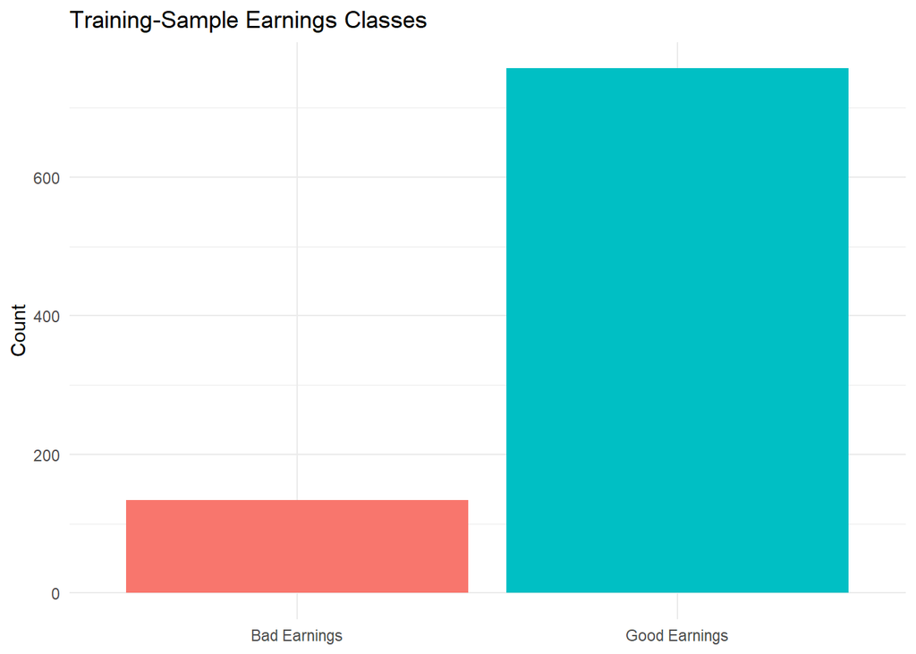

```r
train_data %>%
  dplyr::count(Bad_Earnings) %>%
  mutate(
    Earnings_Class = if_else(
      Bad_Earnings == 1,
      "Bad Earnings",
      "Good Earnings"
    )
  ) %>%
  ggplot(aes(x = Earnings_Class, y = n, fill = Earnings_Class)) +
  geom_col(show.legend = FALSE) +
  labs(
    title = "Training-Sample Earnings Classes",
    x = NULL,
    y = "Count"
  ) +
  theme_minimal()
```

Task: Construct a table containing counts and percentages for good and bad earnings quarters.

```r
earnings_proportions <- train_data %>%
  dplyr::count(Bad_Earnings) %>%
  mutate(
    Earnings_Class = if_else(
      Bad_Earnings == 1,
      "Bad Earnings",
      "Good Earnings"
    ),
    Percent = n / sum(n)
  ) %>%
  select(Earnings_Class, Count = n, Percent)

knitr::kable(
  earnings_proportions,
  digits = 3,
  col.names = c("Earnings Class", "Count", "Percent")
)
```

| Earnings Class | Count | Percent |
| --- | --- | --- |
| Good Earnings | 757 | 0.85 |
| Bad Earnings | 134 | 0.15 |

Q: Any concerns?

A:

- About 15% of the observations are bad earnings quarters, so the classes are imbalanced, but not severely so.
- This imbalance is large enough that accuracy alone could be misleading: a model that predicts every observation as “Good Earnings” would already achieve about 85% accuracy.
- However, 15% is still generally sufficient for standard logistic regression, especially with a reasonably large sample.
- If the bad-earnings class were only 1–2% of the sample, I would be much more concerned. We might have too few bad observations to estimate the model reliably or to evaluate its ability to identify bad quarters.
- There is no single percentage at which class imbalance becomes a problem. The concern depends on the number of minority-class observations, model complexity, and the cost of false positives versus false negatives.
- 15% is imbalanced enough that we should pay attention to evaluation metrics, but not so imbalanced that we necessarily need special modeling techniques.

Task: Compute and plot the bad earnings rate by sector. Also produce a table with the Sector, Number of Companies, Bad Earnings Count, and Bad Earnings Rate.

```r
sector_bad_rates <- train_data %>%
  group_by(Sector) %>%
  summarise(
    Companies = n(),
    Bad_Earnings_Count = sum(Bad_Earnings),
    Bad_Earnings_Rate = mean(Bad_Earnings),
    .groups = "drop"
  ) %>%
  arrange(desc(Bad_Earnings_Rate))

knitr::kable(sector_bad_rates, digits = 3)
```

| Sector | Companies | Bad_Earnings_Count | Bad_Earnings_Rate |
| --- | --- | --- | --- |
| Consumer Staples | 75 | 18 | 0.240 |
| Consumer Discretionary | 105 | 20 | 0.190 |
| Energy | 55 | 10 | 0.182 |
| Financials | 154 | 26 | 0.169 |
| Industrials | 146 | 21 | 0.144 |
| Utilities | 28 | 4 | 0.143 |
| Communication Services | 57 | 8 | 0.140 |
| Materials | 44 | 5 | 0.114 |
| Technology | 114 | 12 | 0.105 |
| Health Care | 113 | 10 | 0.088 |

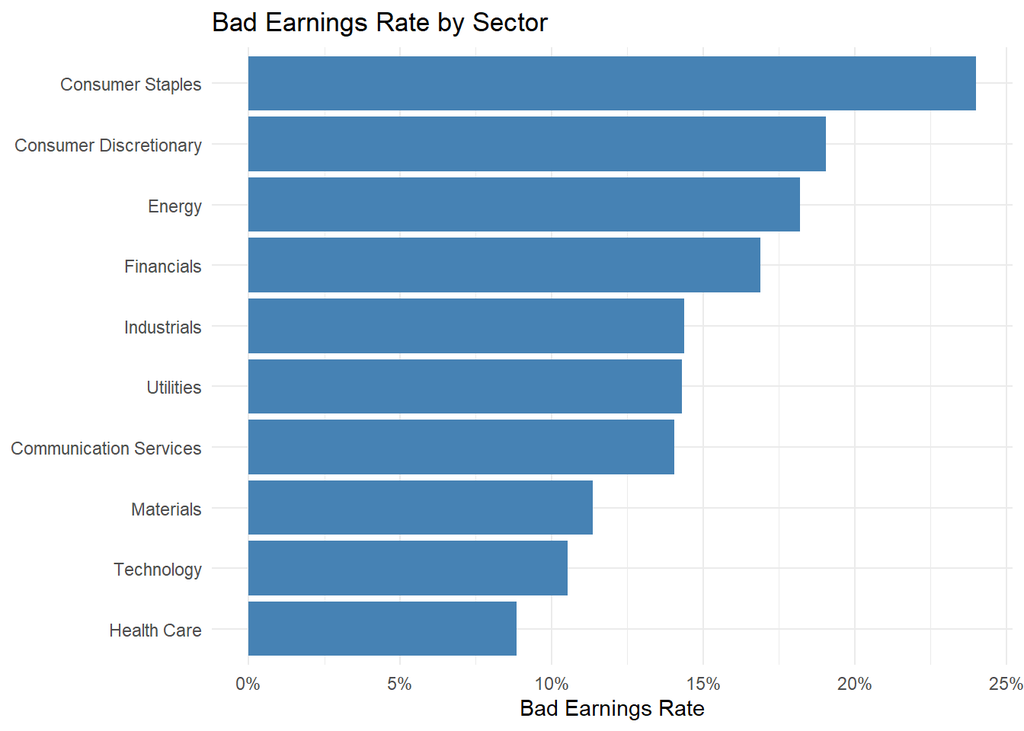

```r
sector_bad_rates %>%
  ggplot(
    aes(
      x = reorder(Sector, Bad_Earnings_Rate),
      y = Bad_Earnings_Rate
    )
  ) +
  geom_col(fill = "steelblue") +
  coord_flip() +
  scale_y_continuous(labels = scales::label_percent(accuracy = 1)) +
  labs(
    title = "Bad Earnings Rate by Sector",
    x = NULL,
    y = "Bad Earnings Rate"
  ) +
  theme_minimal()
```

Q: How might the class imbalance by sector impact our analysis?

A:

- Rate: how common bad earnings are within a sector; helps assess which sector associated with probability of bad earnings
- Count: how many bad earnings observations are in that sector; helps assess how much data we have to estimate that relationship reliably.
- Example: Industrials and Utilites have similar, reasonably high earnigns rates, implying that they should be informative to the probability of bad earnings. But Utilities only has 4 bad earnings observations, so it provides us less information.
- If we later use Sector as a predictor, the coefficient on an indicator for a sector like Utilities may have a relatively large standard error because that sector has relatively few observations, and especially few bad-earnings observations.

## Predictors

Task: Compute and plot the correlations among the numeric predictors.

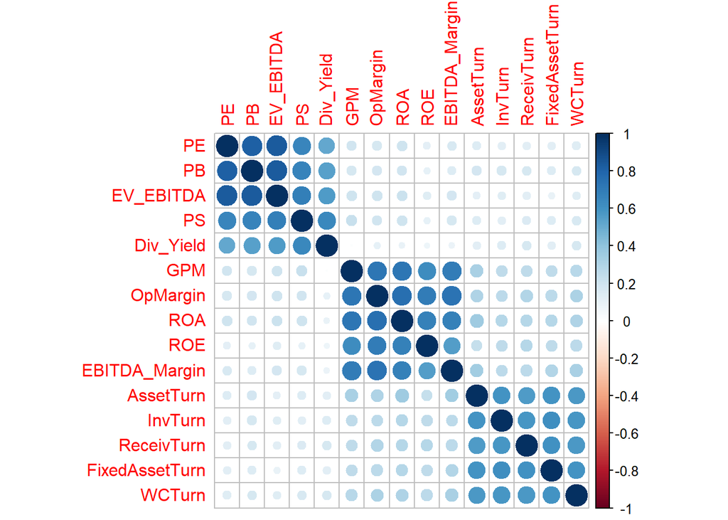

```r
feature_correlations <- train_data %>%
  select(all_of(numeric_feature_names)) %>%
  cor()

corrplot(feature_correlations)
```

Q: What might the correlation matrix suggest about our modeling efforts?

A:

- There is strong commonality among groups of regressors.
- We might be able to reduce the dimensions within each group to conserve degrees of freedom. For now, we’ll model on the entire feature set.

## Connect a Predictor to the Target

Let’s use Gross Profit Margin (GPM) has a primary Predictor. Note: We’re not suggesting this is the most important predictor, but I want to reduce the scope for pedagogical ease. We’ll expand to more predictors later.

Task: For each sector, compare mean standardized GPM between good and bad earnings quarters. Also compute an exploratory two-sample t-test when each group has at least two observations.

```r
sector_gpm_comparison <- train_data %>%
  group_by(Sector) %>%
  summarise(
    Good_Count = sum(Bad_Earnings == 0),
    Bad_Count = sum(Bad_Earnings == 1),
    Mean_GPM_Good = if (
      sum(Bad_Earnings == 0) > 0
    ) {
      mean(GPM[Bad_Earnings == 0])
    } else {
      NA_real_
    },
    Mean_GPM_Bad = if (
      sum(Bad_Earnings == 1) > 0
    ) {
      mean(GPM[Bad_Earnings == 1])
    } else {
      NA_real_
    },
    P_Value = if (
      sum(Bad_Earnings == 0) >= 2 &&
      sum(Bad_Earnings == 1) >= 2
    ) {
      t.test(
        GPM[Bad_Earnings == 0],
        GPM[Bad_Earnings == 1]
      )$p.value
    } else {
      NA_real_
    },
    .groups = "drop"
  ) %>%
  mutate(
    Difference = Mean_GPM_Good - Mean_GPM_Bad
  ) %>%
  select(
    Sector,
    Good_Count,
    Bad_Count,
    Mean_GPM_Good,
    Mean_GPM_Bad,
    Difference,
    P_Value
  ) %>%
  arrange(desc(abs(Difference)))

knitr::kable(sector_gpm_comparison, digits = 3)
```

| Sector | Good_Count | Bad_Count | Mean_GPM_Good | Mean_GPM_Bad | Difference | P_Value |
| --- | --- | --- | --- | --- | --- | --- |
| Consumer Staples | 57 | 18 | 0.184 | -0.989 | 1.174 | 0.000 |
| Energy | 45 | 10 | -0.498 | -1.636 | 1.138 | 0.012 |
| Utilities | 24 | 4 | -0.740 | -1.509 | 0.769 | 0.119 |
| Financials | 128 | 26 | -0.072 | -0.821 | 0.750 | 0.000 |
| Industrials | 125 | 21 | -0.049 | -0.787 | 0.738 | 0.034 |
| Communication Services | 49 | 8 | -0.199 | -0.769 | 0.571 | 0.040 |
| Consumer Discretionary | 85 | 20 | -0.110 | -0.659 | 0.549 | 0.006 |
| Materials | 39 | 5 | 0.022 | -0.504 | 0.526 | 0.124 |
| Health Care | 103 | 10 | 0.505 | 0.091 | 0.413 | 0.101 |
| Technology | 102 | 12 | 0.988 | 0.786 | 0.202 | 0.590 |

Q: What’s the implication of the Differences and PValues?

A:

- The differences are all positive: mean GPM is higher for companies with good earnings than for companies with bad earnings in every sector.
- A majority of these differences are statistically significant at the 5% level.
- Utilities and Materials have relatively few bad-earnings observations. Small group sizes can make the estimated differences less precise and contribute to larger standard errors and p-values.
- However, sample size is not the only determinant of the p-value; the magnitude of the difference and the variability of GPM within each group also matter.
- Technology has the smallest estimated difference and the largest p-value. Its difference is not statistically significant, although Utilities, Materials, and Health Care are also not statistically significant at the 5% level.

Q: Why should we be cautious about these p-values?

A:

- We are running a separate hypothesis test for each sector.
- Each test has some chance of producing a significant result just by chance.
- As the number of tests increases, the probability of getting at least one false positive also increases.
- Therefore, these p-values are useful for exploratory analysis, but we should be cautious about treating p<0.05 in any one sector as strong evidence.
- If we wanted formal inference across all sectors, we could adjust for multiple comparisons using methods such as Bonferroni or false-discovery-rate adjustments; e.g. $\alpha = .05/10 = .005$

Task: Isolate the sector with the largest absolute difference and create side-by-side boxplots with individual observations.

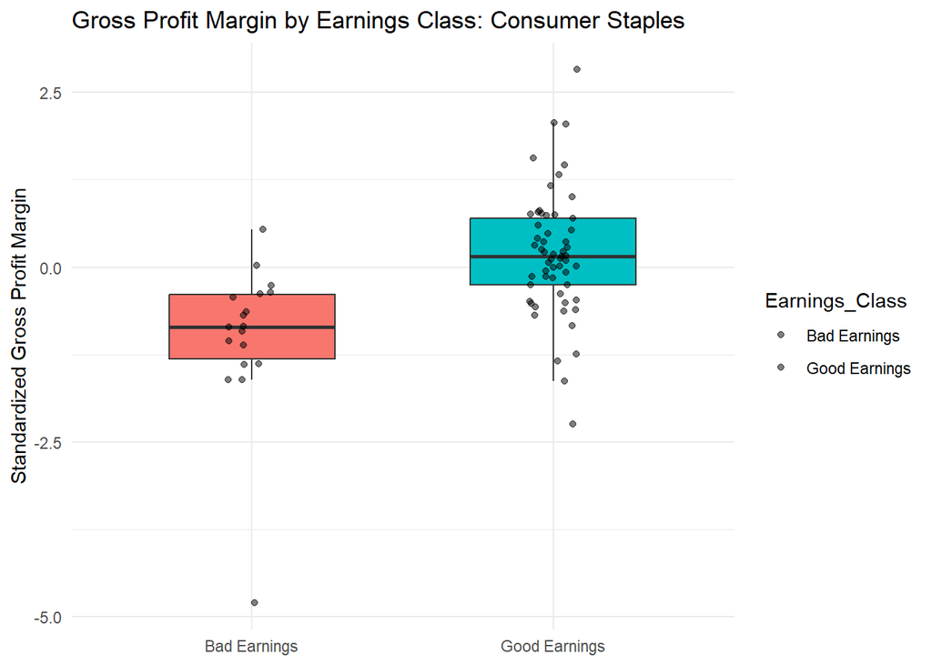

```r
largest_difference_sector <- sector_gpm_comparison %>%
  filter(!is.na(Difference)) %>%
  slice_max(
    order_by = abs(Difference),
    n = 1,
    with_ties = FALSE
  ) %>%
  pull(Sector)

train_data %>%
  filter(Sector == largest_difference_sector) %>%
  mutate(
    Earnings_Class = if_else(
      Bad_Earnings == 1,
      "Bad Earnings",
      "Good Earnings"
    )
  ) %>%
  ggplot(
    aes(
      x = Earnings_Class,
      y = GPM,
      fill = Earnings_Class
    )
  ) +
  geom_boxplot(
    width = 0.55,
    outlier.shape = NA,
    show.legend = FALSE
  ) +
  geom_jitter(width = 0.08, alpha = 0.50) +
  labs(
    title = paste(
      "Gross Profit Margin by Earnings Class:",
      largest_difference_sector
    ),
    x = NULL,
    y = "Standardized Gross Profit Margin"
  ) +
  theme_minimal()
```

Q: Any concerns?

A:

- The difference in GPM means across good/bad earnings companies might be influenced by outliers.
- It might be prudent to explore those observations more carefully and consider robustness checks that subsample to avoid this data.

# Base Model

## Estimate

Task: Estimate a logistic regression on the training sample using gross profit margin as the only predictor.

```r
base_model <- glm(
  Bad_Earnings ~ GPM,
  data = train_data,
  family = binomial(link = "logit")
)
```

## Interpret

Task: Display the model output.

```r
summary(base_model)
```

```
Call:
glm(formula = Bad_Earnings ~ GPM, family = binomial(link = "logit"),
    data = train_data)

Coefficients:
            Estimate Std. Error z value Pr(>|z|)
(Intercept)  -1.9502     0.1108 -17.602  < 2e-16 ***
GPM          -0.8405     0.1091  -7.705  1.3e-14 ***
---
Signif. codes:  0 '***' 0.001 '**' 0.01 '*' 0.05 '.' 0.1 ' ' 1

(Dispersion parameter for binomial family taken to be 1)

    Null deviance: 754.48  on 890  degrees of freedom
Residual deviance: 683.14  on 889  degrees of freedom
AIC: 687.14

Number of Fisher Scoring iterations: 5
```

Q: How interpret the coefficient on GPM?

A:

- The estimated GPM coefficient is -0.8405.
- Because GPM is standardized, a one-standard-deviation increase in gross profit margin is associated with a decline of .8405 in the log odds of the probability of bad earnings.
- The odds ratio is exp(-0.8405) = 0.431, meaning that a one-standard-deviation increase in GPM is associated with a 56.9% decrease in the odds of bad earnings.

Q: Consider a Consumer Staples company. Suppose its starting probability of bad earnings is equal to the observed bad-earnings rate for Consumer Staples. How would a one-standard-deviation increase in GPM affect this probability?

A:

- Recall that o = p/(1-p); where o: odds ratio and p: probability of bad earnings
- So, p = o/(1+o)
- Recall the bad earnings rate for consumer staples was 24%.
- A one-standard-deviation increase in GPM reduces the odds of bad earnings by 56.9%.
- Starting from a 24.0% probability, the odds are 0.316.
- After the increase in GPM, the odds fall to 0.316×0.431=0.136, which corresponds to a probability of approximately 12.0%.
- Thus, the probability of bad earnings falls from 24.0% to about 12.0%, a decline of approximately 12 percentage points.

## Predict

Task: Predict the probability of bad earnings for each company in the test sample.

```r
test_data <- test_data %>%
  mutate(
    base_probability = predict(
      base_model,
      newdata = test_data,
      type = "response"
    )
  )

head(
  test_data %>%
    select(Company_ID, Bad_Earnings, base_probability)
)
```

```
# A tibble: 6 × 3
  Company_ID  Bad_Earnings base_probability
  <chr>              <int>            <dbl>
1 Company0001            0           0.0963
2 Company0003            0           0.159
3 Company0008            0           0.284
4 Company0013            0           0.0338
5 Company0016            0           0.0185
6 Company0028            1           0.326
```

Task: Predict whether a company will have “bad earnings” for two hypothetical companies: one with GPM at the first quartile of the training sample and one with GPM at the third quartile.

```r
gross_margin_quantiles <- quantile(
  train_data$GPM,
  probs = c(0.25, 0.75)
)

base_profiles <- tibble(
  Company = c(
    "First-Quartile Gross Margin",
    "Third-Quartile Gross Margin"
  ),
  GPM = as.numeric(gross_margin_quantiles)
) %>%
  mutate(
    Predicted_Probability = predict(
      base_model,
      newdata = .,
      type = "response"
    ),
    Predicted_Class = as.integer(
      Predicted_Probability >= params$prob_threshold
    )
  )

knitr::kable(base_profiles, digits = 3)
```

| Company | GPM | Predicted_Probability | Predicted_Class |
| --- | --- | --- | --- |
| First-Quartile Gross Margin | -0.637 | 0.196 | 0 |
| Third-Quartile Gross Margin | 0.689 | 0.074 | 0 |

## Classify

Task: Convert the test-sample probabilities into predicted classes using the classification threshold defined earlier.

```r
test_data <- test_data %>%
  mutate(
    base_prediction = as.integer(
      base_probability >= params$prob_threshold
    )
  )

head(
  test_data %>%
    select(
      Company_ID,
      Bad_Earnings,
      base_probability,
      base_prediction
    )
)
```

```
# A tibble: 6 × 4
  Company_ID  Bad_Earnings base_probability base_prediction
  <chr>              <int>            <dbl>           <int>
1 Company0001            0           0.0963               0
2 Company0003            0           0.159                0
3 Company0008            0           0.284                0
4 Company0013            0           0.0338               0
5 Company0016            0           0.0185               0
6 Company0028            1           0.326                0
```

Task: Construct a confusion matrix. Rows are actual classes and columns are predicted classes.

```r
base_confusion <- table(
  Actual = factor(test_data$Bad_Earnings, levels = c(0, 1)),
  Predicted = factor(test_data$base_prediction, levels = c(0, 1))
)

base_confusion
```

```
      Predicted
Actual   0   1
     0 193   0
     1  30   0
```

Q: How do we interpret this confusion matrix?

A:

- The matrix contains 193 true negatives, 0 false positives, 30 false negatives, and 0 true positives.
- A false positive is a good quarter that the model flags as bad.
- A false negative is a bad quarter that the model misses.
- For an investor, false negatives may be especially costly because a company at elevated risk of bad earnings may remain in the portfolio without additional review or an appropriate reduction in its portfolio weight.

Q: Define the following: accuracy, precision, sensitivity, specificity, false-positive rate, false-negative rate, and F1

A:

- Accuracy: The proportion of all predictions that are correct.
- Precision: The proportion of predicted positives that are actually positive.
- Sensitivity: The proportion of actual positives that are correctly identified. (aka recall)
- Specificity: The proportion of actual negatives that are correctly identified.
- False-positive rate: The proportion of actual negatives that are incorrectly classified as positive.
- False-negative rate: The proportion of actual positives that are incorrectly classified as negative.
- F1 score: The harmonic mean of precision and sensitivity
  - $2\times(Precision\times Sensitivity)/(Precision+Sensitivity)$
  - Range 0 to 1
  - High only when precision and sensitivity are both high

Q: Can you translate the metrics above within our case study?

A:

- Accuracy: Proportion of all companies in the test sample that are predicted to have good or bad earnings correctly
- Precision: Proportion of companies that we predicted to have bad earnings that actually had bad earnings
- Sensitivity: Proportion of company that actually had bad earnings that we predicted to have bad earnings
- Specificity: Proportion of actual good earnings companies that we predicted to have good earnings
- False Positive Rate: Proportion of actual good earnings companies that we predicted as bad earnings
- False Negative Rate: Proportion of actual bad earnings companies that we predicted as good earnings
- F1 Score:

Q: Why F1 important in our dataset?

A:

Task: Define a function that computes the main classification metrics.

```r
classification_metrics <- function(actual, predicted) {
  confusion <- table(
    Actual = factor(actual, levels = c(0, 1)),
    Predicted = factor(predicted, levels = c(0, 1))
  )

  true_negative <- as.numeric(confusion["0", "0"])
  false_positive <- as.numeric(confusion["0", "1"])
  false_negative <- as.numeric(confusion["1", "0"])
  true_positive <- as.numeric(confusion["1", "1"])

  safe_divide <- function(numerator, denominator) {
    if (denominator == 0) {
      NA_real_
    } else {
      numerator / denominator
    }
  }

  accuracy <- safe_divide(
    true_positive + true_negative,
    true_positive + true_negative + false_positive + false_negative
  )
  precision <- safe_divide(
    true_positive,
    true_positive + false_positive
  )
  sensitivity <- safe_divide(
    true_positive,
    true_positive + false_negative
  )
  specificity <- safe_divide(
    true_negative,
    true_negative + false_positive
  )
  false_positive_rate <- safe_divide(
    false_positive,
    false_positive + true_negative
  )
  false_negative_rate <- safe_divide(
    false_negative,
    false_negative + true_positive
  )

  if (is.na(precision) || is.na(sensitivity)) {
    f1 <- NA_real_
  } else if (precision + sensitivity == 0) {
    f1 <- 0
  } else {
    f1 <- 2 * precision * sensitivity / (precision + sensitivity)
  }

  tibble(
    Metric = c(
      "Accuracy",
      "Precision",
      "Sensitivity (Recall)",
      "Specificity",
      "False Positive Rate (Type I)",
      "False Negative Rate (Type II)",
      "F1"
    ),
    Value = c(
      accuracy,
      precision,
      sensitivity,
      specificity,
      false_positive_rate,
      false_negative_rate,
      f1
    )
  )
}

get_metric <- function(metrics, metric_name) {
  metrics %>%
    filter(Metric == metric_name) %>%
    pull(Value)
}

format_rate <- function(value) {
  if (length(value) == 0 || is.na(value)) {
    "undefined"
  } else {
    scales::percent(value, accuracy = 0.1)
  }
}
```

Task: Compute accuracy, precision, sensitivity, specificity, false-positive rate, false-negative rate, and F1.

```r
base_metrics <- classification_metrics(
  test_data$Bad_Earnings,
  test_data$base_prediction
)

knitr::kable(base_metrics, digits = 3)
```

| Metric | Value |
| --- | --- |
| Accuracy | 0.865 |
| Precision | NA |
| Sensitivity (Recall) | 0.000 |
| Specificity | 1.000 |
| False Positive Rate (Type I) | 0.000 |
| False Negative Rate (Type II) | 1.000 |
| F1 | NA |

```r
no_information_rate <- max(
  mean(test_data$Bad_Earnings == 0),
  mean(test_data$Bad_Earnings == 1)
)
```

Q: How do we interpret these metrics?

A: At the 65% threshold, the base model has accuracy of 86.5%, precision of undefined, sensitivity of 0.0%, specificity of 100.0%, and F1 of undefined. Sensitivity measures the share of actual bad quarters detected, while precision measures the share of flagged quarters that are actually bad. Because bad quarters are a minority class, accuracy should be compared with the 86.5% accuracy obtained by always predicting the majority class. A metric is reported as undefined when its denominator is zero, such as precision when the model predicts no bad quarters.

Q: Is this a good classifier?

A: No. The classifier predicts that every company will have good earnings. It achieves 86.5% accuracy only because bad earnings are relatively uncommon. Its sensitivity is 0%, meaning it fails to identify any bad-earnings companies.

Task: Construct the ROC curve.

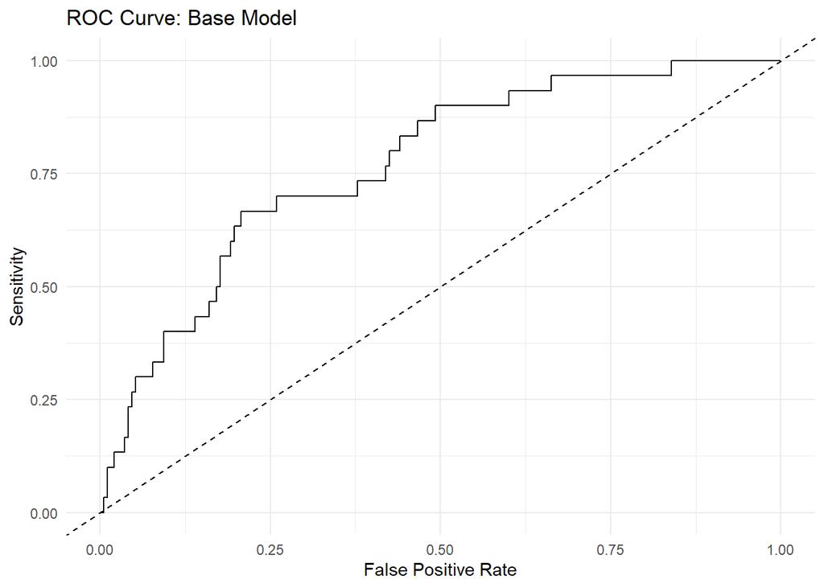

```r
base_roc <- pROC::roc(
  response = test_data$Bad_Earnings,
  predictor = test_data$base_probability,
  levels = c(0, 1),
  direction = "<",
  quiet = TRUE
)

pROC::ggroc(base_roc, legacy.axes = TRUE) +
  geom_abline(
    intercept = 0,
    slope = 1,
    linetype = "dashed"
  ) +
  labs(
    title = "ROC Curve: Base Model",
    x = "False Positive Rate",
    y = "Sensitivity"
  ) +
  theme_minimal()
```

Q: How do we interpret the ROC curve?

A: Each point represents a different classification threshold. Moving toward higher sensitivity generally requires accepting a higher false-positive rate. The dashed diagonal represents random ranking. A curve closer to the upper-left corner indicates better discrimination between good and bad earnings quarters. Unlike a confusion matrix, the ROC curve evaluates the ranking of predicted probabilities across many probability thresholds.

Task: Compute the area under the ROC curve.

```r
base_auc <- as.numeric(pROC::auc(base_roc))
base_auc
```

```
[1] 0.7689119
```

Q: How do we interpret the AUC?

A: The base-model AUC is 0.769. An AUC of 0.50 indicates no ranking ability beyond chance, while an AUC of 1.00 indicates perfect ranking. Equivalently, the model assigns a higher predicted probability to a randomly selected bad quarter than to a randomly selected good quarter in approximately 76.9% of such pairs.

# Alternative Model

## Estimate

Task: Estimate a logistic regression using all predictors.

```r
alt_formula <- reformulate(
  termlabels = feature_names,
  response = "Bad_Earnings"
)

alt_model <- glm(
  alt_formula,
  data = train_data,
  family = binomial(link = "logit")
)
```

## Interpret

Task: Display the coefficient on GPM in the alternative model.

```r
summary(alt_model)
```

```
Call:
glm(formula = alt_formula, family = binomial(link = "logit"),
    data = train_data)

Coefficients:
                             Estimate Std. Error z value Pr(>|z|)
(Intercept)                  -2.15298    0.42283  -5.092 3.54e-07 ***
SectorConsumer Discretionary  0.12322    0.50356   0.245 0.806688
SectorConsumer Staples        0.64824    0.54566   1.188 0.234832
SectorEnergy                 -0.42968    0.61064  -0.704 0.481641
SectorFinancials             -0.11479    0.51287  -0.224 0.822901
SectorHealth Care            -0.55601    0.57545  -0.966 0.333931
SectorIndustrials            -0.17500    0.49413  -0.354 0.723222
SectorMaterials              -0.12831    0.66784  -0.192 0.847643
SectorTechnology             -0.25866    0.63523  -0.407 0.683866
SectorUtilities               0.38475    0.77485   0.497 0.619506
PE                           -0.02432    0.22832  -0.107 0.915165
PB                            0.15824    0.19936   0.794 0.427356
EV_EBITDA                     0.74626    0.22125   3.373 0.000744 ***
PS                           -0.06573    0.17941  -0.366 0.714083
Div_Yield                    -0.10604    0.17653  -0.601 0.548046
GPM                          -0.21648    0.21820  -0.992 0.321142
OpMargin                     -0.32679    0.21365  -1.530 0.126135
ROA                          -0.28239    0.20864  -1.354 0.175895
ROE                          -0.13819    0.27118  -0.510 0.610327
EBITDA_Margin                -0.41244    0.19559  -2.109 0.034969 *
AssetTurn                    -0.10288    0.18015  -0.571 0.567951
InvTurn                      -0.29976    0.17840  -1.680 0.092903 .
ReceivTurn                    0.01608    0.16248   0.099 0.921164
FixedAssetTurn               -0.05968    0.16861  -0.354 0.723371
WCTurn                        0.06495    0.16578   0.392 0.695210
---
Signif. codes:  0 '***' 0.001 '**' 0.01 '*' 0.05 '.' 0.1 ' ' 1

(Dispersion parameter for binomial family taken to be 1)

    Null deviance: 754.48  on 890  degrees of freedom
Residual deviance: 596.94  on 866  degrees of freedom
AIC: 646.94

Number of Fisher Scoring iterations: 6
```

Q: What differences do you notice about the GPM coefficient. Why might that be the case?

A:

- The GPM coefficient is now smaller in magnitude and statistically insignificant.
- Most likely some of the other features are correlated with GPM, leading to multicollinearity, thereby attentuating the coefficient.

Task: Display all model coefficients, sorted by p-value.

```r
alt_coefficients <- as.data.frame(
  coef(summary(alt_model))
) %>%
  tibble::rownames_to_column("Predictor") %>%
  as_tibble() %>%
  rename(
    Standard_Error = `Std. Error`,
    z_value = `z value`,
    p_value = `Pr(>|z|)`
  ) %>%
  filter(Predictor != "(Intercept)") %>%
  mutate(
    Odds_Ratio = exp(Estimate),
    Absolute_Estimate = abs(Estimate)
  ) %>%
  arrange(p_value)

knitr::kable(
  alt_coefficients %>%
    select(
      Predictor,
      Estimate,
      Standard_Error,
      z_value,
      p_value,
      Odds_Ratio
    ),
  digits = 3
)
```

| Predictor | Estimate | Standard_Error | z_value | p_value | Odds_Ratio |
| --- | --- | --- | --- | --- | --- |
| EV_EBITDA | 0.746 | 0.221 | 3.373 | 0.001 | 2.109 |
| EBITDA_Margin | -0.412 | 0.196 | -2.109 | 0.035 | 0.662 |
| InvTurn | -0.300 | 0.178 | -1.680 | 0.093 | 0.741 |
| OpMargin | -0.327 | 0.214 | -1.530 | 0.126 | 0.721 |
| ROA | -0.282 | 0.209 | -1.354 | 0.176 | 0.754 |
| SectorConsumer Staples | 0.648 | 0.546 | 1.188 | 0.235 | 1.912 |
| GPM | -0.216 | 0.218 | -0.992 | 0.321 | 0.805 |
| SectorHealth Care | -0.556 | 0.575 | -0.966 | 0.334 | 0.573 |
| PB | 0.158 | 0.199 | 0.794 | 0.427 | 1.171 |
| SectorEnergy | -0.430 | 0.611 | -0.704 | 0.482 | 0.651 |
| Div_Yield | -0.106 | 0.177 | -0.601 | 0.548 | 0.899 |
| AssetTurn | -0.103 | 0.180 | -0.571 | 0.568 | 0.902 |
| ROE | -0.138 | 0.271 | -0.510 | 0.610 | 0.871 |
| SectorUtilities | 0.385 | 0.775 | 0.497 | 0.620 | 1.469 |
| SectorTechnology | -0.259 | 0.635 | -0.407 | 0.684 | 0.772 |
| WCTurn | 0.065 | 0.166 | 0.392 | 0.695 | 1.067 |
| PS | -0.066 | 0.179 | -0.366 | 0.714 | 0.936 |
| SectorIndustrials | -0.175 | 0.494 | -0.354 | 0.723 | 0.839 |
| FixedAssetTurn | -0.060 | 0.169 | -0.354 | 0.723 | 0.942 |
| SectorConsumer Discretionary | 0.123 | 0.504 | 0.245 | 0.807 | 1.131 |
| SectorFinancials | -0.115 | 0.513 | -0.224 | 0.823 | 0.892 |
| SectorMaterials | -0.128 | 0.668 | -0.192 | 0.848 | 0.880 |
| PE | -0.024 | 0.228 | -0.107 | 0.915 | 0.976 |
| ReceivTurn | 0.016 | 0.162 | 0.099 | 0.921 | 1.016 |

```r
top_alt_terms <- alt_coefficients %>%
  filter(!is.na(p_value)) %>%
  slice_head(n = 3) %>%
  pull(Predictor)
```

Q: Which model terms show the strongest conditional associations with bad earnings, and why is that not the same as definitive predictor importance?

A:

- The smallest p-values belong to EV_EBITDA and EBITDA_Margin
- These terms show the strongest evidence of conditional association with bad earnings in the fitted model.
- However, small p-values do not necessarily mean that these variables are the most useful for prediction.
- P-values depend on coefficient magnitude, standard errors, sample size, multicollinearity, and model specification.
- For standardized numeric predictors, coefficient magnitudes can be compared cautiously, while sector coefficients represent comparisons with the reference sector. Ultimately, the model’s predictive ability should be evaluated on the test sample; assessing the predictive importance of individual variables requires an additional method, such as permutation importance.

## Predict

Task: Predict the probability of bad earnings for each company in the test sample.

```r
test_data <- test_data %>%
  mutate(
    alt_probability = predict(
      alt_model,
      newdata = test_data,
      type = "response"
    )
  )

head(
  test_data %>%
    select(Company_ID, Bad_Earnings, alt_probability)
)
```

```
# A tibble: 6 × 3
  Company_ID  Bad_Earnings alt_probability
  <chr>              <int>           <dbl>
1 Company0001            0          0.0923
2 Company0003            0          0.177
3 Company0008            0          0.0423
4 Company0013            0          0.0314
5 Company0016            0          0.0114
6 Company0028            1          0.557
```

Task: Predict bad earnings for two hypothetical companies: one with GPM at the first quartile and one with GPM at the third quartile. Hold all other numeric predictors at their training-sample means and all categorical predictors at their most common training-sample values.

```r
most_common_value <- function(x) {
  unique_values <- unique(x)
  unique_values[
    which.max(
      tabulate(match(x, unique_values))
    )
  ]
}

reference_numeric_profile <- train_data %>%
  summarise(
    across(all_of(numeric_feature_names), mean)
  )

reference_categorical_profile <- train_data %>%
  summarise(
    across(
      all_of(categorical_feature_names),
      most_common_value
    )
  )

reference_profile <- bind_cols(
  reference_numeric_profile,
  reference_categorical_profile
)

alt_profiles <- bind_rows(
  reference_profile,
  reference_profile
) %>%
  mutate(
    Company = c(
      "First-Quartile Gross Margin",
      "Third-Quartile Gross Margin"
    ),
    GPM = as.numeric(gross_margin_quantiles)
  ) %>%
  mutate(
    Predicted_Probability = predict(
      alt_model,
      newdata = .,
      type = "response"
    ),
    Predicted_Class = as.integer(
      Predicted_Probability >= params$prob_threshold
    )
  ) %>%
  relocate(Company)

knitr::kable(
  alt_profiles %>%
    select(
      Company,
      GPM,
      Predicted_Probability,
      Predicted_Class
    ),
  digits = 3
)
```

| Company | GPM | Predicted_Probability | Predicted_Class |
| --- | --- | --- | --- |
| First-Quartile Gross Margin | -0.637 | 0.106 | 0 |
| Third-Quartile Gross Margin | 0.689 | 0.082 | 0 |

## Classify

Task: Convert the alternative-model probabilities into predicted classes using the classification threshold defined earlier.

```r
test_data <- test_data %>%
  mutate(
    alt_prediction = as.integer(
      alt_probability >= params$prob_threshold
    )
  )

head(
  test_data %>%
    select(
      Company_ID,
      Bad_Earnings,
      alt_probability,
      alt_prediction
    )
)
```

```
# A tibble: 6 × 4
  Company_ID  Bad_Earnings alt_probability alt_prediction
  <chr>              <int>           <dbl>          <int>
1 Company0001            0          0.0923              0
2 Company0003            0          0.177               0
3 Company0008            0          0.0423              0
4 Company0013            0          0.0314              0
5 Company0016            0          0.0114              0
6 Company0028            1          0.557               0
```

Task: Construct a confusion matrix. Rows are actual classes and columns are predicted classes.

```r
alt_confusion <- table(
  Actual = factor(test_data$Bad_Earnings, levels = c(0, 1)),
  Predicted = factor(test_data$alt_prediction, levels = c(0, 1))
)

alt_confusion
```

```
      Predicted
Actual   0   1
     0 192   1
     1  26   4
```

Q: How do we interpret this confusion matrix?

A:

- The matrix contains 192 true negatives, 1 false positives, 26 false negatives, and 4 true positives.
- Immediately we see that this alt model does indeed predict some companies to have bad earnings

Task: Compute the classification metrics.

```r
alt_metrics <- classification_metrics(
  test_data$Bad_Earnings,
  test_data$alt_prediction
)

knitr::kable(alt_metrics, digits = 3)
```

| Metric | Value |
| --- | --- |
| Accuracy | 0.879 |
| Precision | 0.800 |
| Sensitivity (Recall) | 0.133 |
| Specificity | 0.995 |
| False Positive Rate (Type I) | 0.005 |
| False Negative Rate (Type II) | 0.867 |
| F1 | 0.229 |

Q: How do we interpret these metrics?

A:

- The alt model is quite accuract (87.9% of predictions are true)
- But given the small number of bad earnings companies that may not be reliable.
- False negative rate (i.e. predict good earnings but actually bad) is over 86%.
- The F1 score, which balances the accuracy of predicting rare bad earnings with false alarms, is low at 22.9%.

Task: Compute the AUC.

```r
alt_roc <- pROC::roc(
  response = test_data$Bad_Earnings,
  predictor = test_data$alt_prediction,
  levels = c(0, 1),
  direction = "<",
  quiet = TRUE
)

alt_auc <- as.numeric(pROC::auc(alt_roc))
alt_auc
```

```
[1] 0.564076
```

# Compare the Models

Task: Create a table comparing the classification metrics and ROC AUC of the two models.

```r
model_comparison <- base_metrics %>%
  rename(`Base Model` = Value) %>%
  left_join(
    alt_metrics %>%
      rename(`Alternative Model` = Value),
    by = "Metric"
  ) %>%
  bind_rows(
    tibble(
      Metric = "ROC AUC",
      `Base Model` = base_auc,
      `Alternative Model` = alt_auc
    )
  )

knitr::kable(model_comparison, digits = 3)
```

| Metric | Base Model | Alternative Model |
| --- | --- | --- |
| Accuracy | 0.865 | 0.879 |
| Precision | NA | 0.800 |
| Sensitivity (Recall) | 0.000 | 0.133 |
| Specificity | 1.000 | 0.995 |
| False Positive Rate (Type I) | 0.000 | 0.005 |
| False Negative Rate (Type II) | 1.000 | 0.867 |
| F1 | NA | 0.229 |
| ROC AUC | 0.769 | 0.564 |

Task: Plot the two ROC curves together.

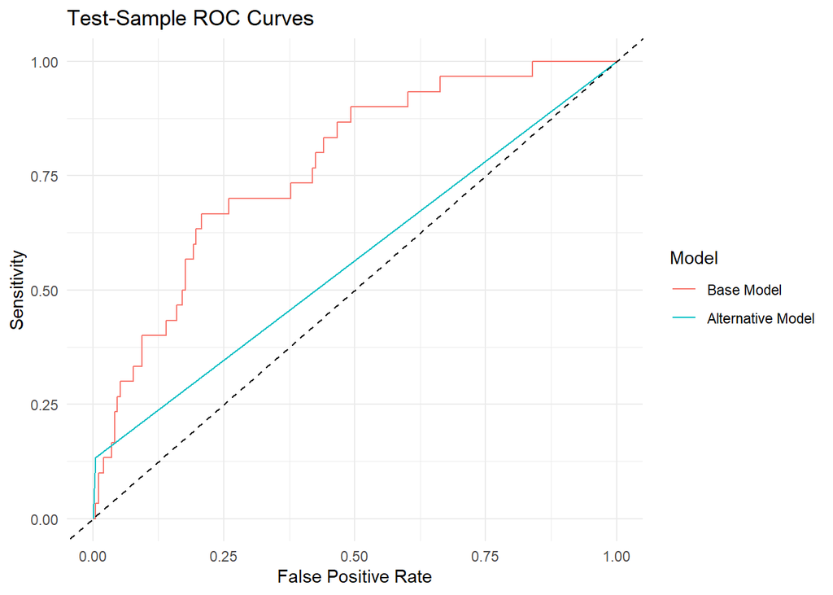

```r
roc_models <- list(
  `Base Model` = base_roc,
  `Alternative Model` = alt_roc
)

pROC::ggroc(roc_models, legacy.axes = TRUE) +
  geom_abline(
    intercept = 0,
    slope = 1,
    linetype = "dashed"
  ) +
  labs(
    title = "Test-Sample ROC Curves",
    x = "False Positive Rate",
    y = "Sensitivity",
    color = "Model"
  ) +
  theme_minimal()
```

Q: Which model appears better?

# Threshold Analysis

The analyses below use the holdout sample to illustrate how definitions and decision rules affect measured performance. In an applied project, do not use these tables to tune a threshold and then report performance on the same holdout sample as a final result. Select thresholds with a validation sample or cross-validation, and reserve a separate test sample for one final evaluation.

## Classification-Probability Threshold

Task: Create a vector of alternative classification-probability thresholds.

```r
prob_thresholds <- c(0.35, 0.45, 0.55, 0.65, 0.75, 0.85)
prob_thresholds
```

```
[1] 0.35 0.45 0.55 0.65 0.75 0.85
```

Task: Reclassify the alternative model’s existing probabilities at each threshold. For each threshold, compute sensitivity, specificity, false-positive rate, and false-negative rate.

```r
prob_threshold_results <- lapply(
  prob_thresholds,
  function(threshold) {
    predicted_class <- as.integer(
      test_data$alt_probability >= threshold
    )

    metrics <- classification_metrics(
      test_data$Bad_Earnings,
      predicted_class
    )

    tibble(
      Probability_Threshold = threshold,
      Predicted_Bad_Rate = mean(predicted_class),
      Sensitivity = get_metric(
        metrics,
        "Sensitivity (Recall)"
      ),
      Specificity = get_metric(
        metrics,
        "Specificity"
      ),
      False_Positive_Rate = get_metric(
        metrics,
        "False Positive Rate (Type I)"
      ),
      False_Negative_Rate = get_metric(
        metrics,
        "False Negative Rate (Type II)"
      )
    )
  }
) %>%
  bind_rows()

knitr::kable(prob_threshold_results, digits = 3)
```

| Probability_Threshold | Predicted_Bad_Rate | Sensitivity | Specificity | False_Positive_Rate | False_Negative_Rate |
| --- | --- | --- | --- | --- | --- |
| 0.35 | 0.085 | 0.367 | 0.959 | 0.041 | 0.633 |
| 0.45 | 0.054 | 0.300 | 0.984 | 0.016 | 0.700 |
| 0.55 | 0.036 | 0.233 | 0.995 | 0.005 | 0.767 |
| 0.65 | 0.022 | 0.133 | 0.995 | 0.005 | 0.867 |
| 0.75 | 0.009 | 0.067 | 1.000 | 0.000 | 0.933 |
| 0.85 | 0.004 | 0.033 | 1.000 | 0.000 | 0.967 |

Task: Plot sensitivity and specificity against the probability threshold.

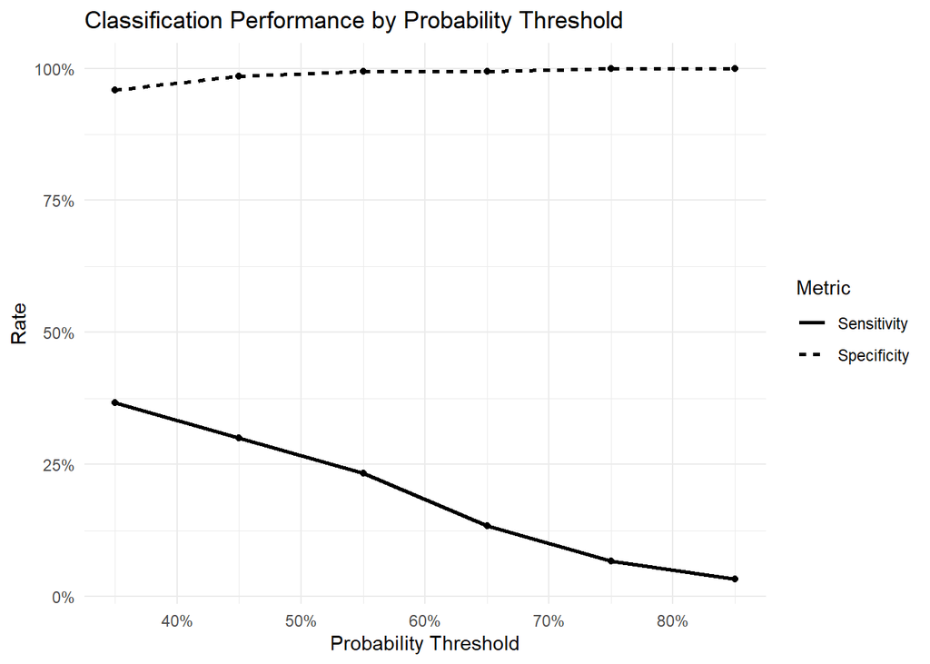

```r
prob_threshold_results %>%
  select(
    Probability_Threshold,
    Sensitivity,
    Specificity
  ) %>%
  pivot_longer(
    cols = c(Sensitivity, Specificity),
    names_to = "Metric",
    values_to = "Value"
  ) %>%
  ggplot(
    aes(
      x = Probability_Threshold,
      y = Value,
      linetype = Metric
    )
  ) +
  geom_line(linewidth = 1) +
  geom_point() +
  scale_x_continuous(labels = scales::label_percent(accuracy = 1)) +
  scale_y_continuous(labels = scales::label_percent(accuracy = 1)) +
  labs(
    title = "Classification Performance by Probability Threshold",
    x = "Probability Threshold",
    y = "Rate",
    linetype = "Metric"
  ) +
  theme_minimal()
```

Q: Why do these metrics change with `prob_threshold`?

A: The predicted probabilities do not change; only the point at which they are converted into classes changes. Raising the threshold causes fewer observations to be classified as bad. Therefore, sensitivity generally falls, specificity rises, the false-positive rate falls, and the false-negative rate rises. Lowering the threshold produces the opposite trade-off.

Q: Why is this trade-off relevant for the portfolio manager?

A: A lower threshold identifies more potentially risky companies but also flags more companies that ultimately report good earnings. A higher threshold reduces unnecessary reviews or portfolio adjustments but misses more genuinely bad earnings quarters. The portfolio manager should select the threshold by comparing the cost of retaining an undetected risky company with the cost of unnecessarily underweighting or excluding a company that ultimately performs well. The research team’s capacity to investigate flagged companies may also affect the choice.

## Target-Definition Threshold

The values below are quantiles used to define the observed target. They are not probability thresholds.

Task: Create a vector of alternative lower-tail quantiles for defining bad earnings.

```r
bad_quantiles <- c(0.01, 0.05, 0.10, 0.15, 0.20, 0.25)
bad_quantiles
```

```
[1] 0.01 0.05 0.10 0.15 0.20 0.25
```

Task: For each quantile, compute the percent of the training sample that is bad, the percent for the test sample, the sensitivity and the specificity.

```r
#| warning: true

bad_quantile_results <- lapply(
  bad_quantiles,
  function(bad_quantile) {

    # Define bad earnings using the training-sample cutoff
    earnings_cutoff <- as.numeric(
      quantile(
        train_data$Quarterly_Earnings_Growth,
        probs = bad_quantile
      )
    )

    # Recreate the target in the training and test samples
    threshold_train <- train_data %>%
      mutate(
        Target_Bad_Earnings = as.integer(
          Quarterly_Earnings_Growth <= earnings_cutoff
        )
      )

    threshold_test <- test_data %>%
      mutate(
        Target_Bad_Earnings = as.integer(
          Quarterly_Earnings_Growth <= earnings_cutoff
        )
      )

    # Refit the logistic model
    threshold_formula <- reformulate(
      termlabels = feature_names,
      response = "Target_Bad_Earnings"
    )

    threshold_model <- glm(
      threshold_formula,
      data = threshold_train,
      family = binomial(link = "logit")
    )

    # Predict the test sample
    threshold_probability <- predict(
      threshold_model,
      newdata = threshold_test,
      type = "response"
    )

    threshold_prediction <- as.integer(
      threshold_probability >= params$prob_threshold
    )

    # Compute classification metrics
    metrics <- classification_metrics(
      threshold_test$Target_Bad_Earnings,
      threshold_prediction
    )

    tibble(
      Bad_Quantile = bad_quantile,
      Earnings_Growth_Cutoff = earnings_cutoff,
      Training_Bad_Rate = mean(
        threshold_train$Target_Bad_Earnings
      ),
      Test_Bad_Rate = mean(
        threshold_test$Target_Bad_Earnings
      ),
      Sensitivity = get_metric(
        metrics,
        "Sensitivity (Recall)"
      ),
      Specificity = get_metric(
        metrics,
        "Specificity"
      )
    )
  }
) %>%
  bind_rows()

# Display the results
bad_quantile_results %>%
  mutate(
    across(
      c(
        Training_Bad_Rate,
        Test_Bad_Rate,
        Sensitivity,
        Specificity
      ),
      ~ scales::percent(.x, accuracy = 0.1)
    )
  ) %>%
  knitr::kable()
```

| Bad_Quantile | Earnings_Growth_Cutoff | Training_Bad_Rate | Test_Bad_Rate | Sensitivity | Specificity |
| --- | --- | --- | --- | --- | --- |
| 0.01 | -4.6340208 | 1.0% | 0.9% | 0.0% | 99.1% |
| 0.05 | -1.9472798 | 5.1% | 4.5% | 10.0% | 100.0% |
| 0.10 | -0.8400274 | 10.1% | 9.4% | 4.8% | 100.0% |
| 0.15 | -0.0057936 | 15.0% | 13.5% | 13.3% | 99.5% |
| 0.20 | 0.4353803 | 20.1% | 19.3% | 14.0% | 98.3% |
| 0.25 | 0.9400692 | 25.0% | 25.6% | 15.8% | 98.2% |

Q: Why do the metrics change when the target-definition quantile changes?

A:

- Changing the quantile changes which observations count as bad, the prevalence of the positive class, and the model that is estimated.
- Unlike a change in `prob_threshold`, this is not merely a new decision rule applied to the same probabilities. The pattern need not be monotonic.
- Very low quantiles create a rare target with few positive observations, which can make coefficient estimates and performance metrics unstable; some metrics may even be undefined when the test sample contains no positive cases or the model predicts no positive cases.

Q: Why is the target definition relevant for the portfolio manager?

A:

- The target definition determines the investment-risk event the model is trying to predict.
- A narrower lower-tail definition focuses on the most severe earnings outcomes but provides fewer positive observations for estimating and evaluating the model.
- A broader definition supplies more observations but may group moderately weak quarters with genuinely severe earnings events.
- The portfolio manager should choose the definition before model selection and align it with the portfolio’s investment objective, downside-risk tolerance, and capacity to investigate or act on flagged companies.